# TO404 Homework Assignment 1

Richard Einhorn

Assigned: Oct 24, 2020, Due Sun Nov 01, 2020 11:59PM

# 1 Setup

```r
#install.packages("nycflights13")
library(nycflights13)  # import data
library(ggplot2)  # used in visualizations
library(dplyr)  # used in data frame manipulations
nyc <- nycflights13::flights  # assign data to nyc data frame
```

Let’s take a look at the data:

```r
head(nyc)
```

```
## # A tibble: 6 x 19
##    year month   day dep_time sched_dep_time dep_delay arr_time sched_arr_time
##   <int> <int> <int>    <int>          <int>     <dbl>    <int>          <int>
## 1  2013     1     1      517            515         2      830            819
## 2  2013     1     1      533            529         4      850            830
## 3  2013     1     1      542            540         2      923            850
## 4  2013     1     1      544            545        -1     1004           1022
## 5  2013     1     1      554            600        -6      812            837
## 6  2013     1     1      554            558        -4      740            728
## # ... with 11 more variables: arr_delay <dbl>, carrier <chr>, flight <int>,
## #   tailnum <chr>, origin <chr>, dest <chr>, air_time <dbl>, distance <dbl>,
## #   hour <dbl>, minute <dbl>, time_hour <dttm>
```

# 2 Basic Exploration

Let’s first do some simple exploration of this data.

## 2.1 How many airlines are there?

```r
length(table(na.omit(nyc$carrier)))
```

```
## [1] 16
```

There are 16 airlines in total.

## 2.2 How many flights there were by the airline with code OO?

```r
nrow(na.omit(nyc[nyc$carrier == "OO",]))
```

```
## [1] 29
```

There were a total of 29 flights by the airline with code OO.

## 2.3 How long is the shortest flight out of any NYC airport??

```r
min(nyc$air_time, na.rm = TRUE)
```

```
## [1] 20
```

The shortest flight recorded took 20 minutes.

## 2.4 How many flights were there by United Airlines on Jan 12th 2013?

```r
nrow(na.omit(nyc[nyc$carrier == "UA" & nyc$month == '1' & nyc$day == '12',]))
```

```
## [1] 110
```

There were 110 flights by UA on Jan 12th 2013.

# 3 Arrival Delay

Lets focus on Arrival Delay.

## 3.1 What was the average arrival delay?

```r
mean(na.omit(nyc[nyc$month == '1',]$arr_delay))
```

```
## [1] 6.129972
```

The average arrival delay for all airports and all airlines combined in Jan 2013 was equal to about 6 minutes.

## 3.2 What was the median arrival delay?

```r
median(na.omit(nyc[nyc$month == '1',]$arr_delay))
```

```
## [1] -3
```

> We see that the average flight delay was around 6 minutes indicating that, overall, flights from NYC airports were efficient (assuming that passengers do not seriously mind a delay of a few minutes). The difference between the mean and the median suggests that the data is skewed (to the right), meaning that there is a few flights which are massively delayed hence have a large impact on the mean. It could be argued that passengers are probably more interested in the median flight arrival delay as most flights (i.e. more than 50%) do not have any arrival delay (in fact, the majority of flights in the dataset arrive early).

# 4 Airline Performance

Lets see if all airlines are equally terrible as far as flight arrival delays are concerned.

## 4.1 What is the average arrival delay by airline?

```r
nyc$carrier <- as.factor(nyc$carrier) # ensuring that airline column in data set
# is coded as a factor

carrier_delay = tapply(nyc$arr_delay, nyc$carrier, mean, na.rm = TRUE)
knitr::kable(carrier_delay, col.names="Average arrival delay (in minutes)", digits = 2)
```

|  | Average arrival delay (in minutes) |
| --- | --- |
| 9E | 7.38 |
| AA | 0.36 |
| AS | -9.93 |
| B6 | 9.46 |
| DL | 1.64 |
| EV | 15.80 |
| F9 | 21.92 |
| FL | 20.12 |
| HA | -6.92 |
| MQ | 10.77 |
| OO | 11.93 |
| UA | 3.56 |
| US | 2.13 |
| VX | 1.76 |
| WN | 9.65 |
| YV | 15.56 |

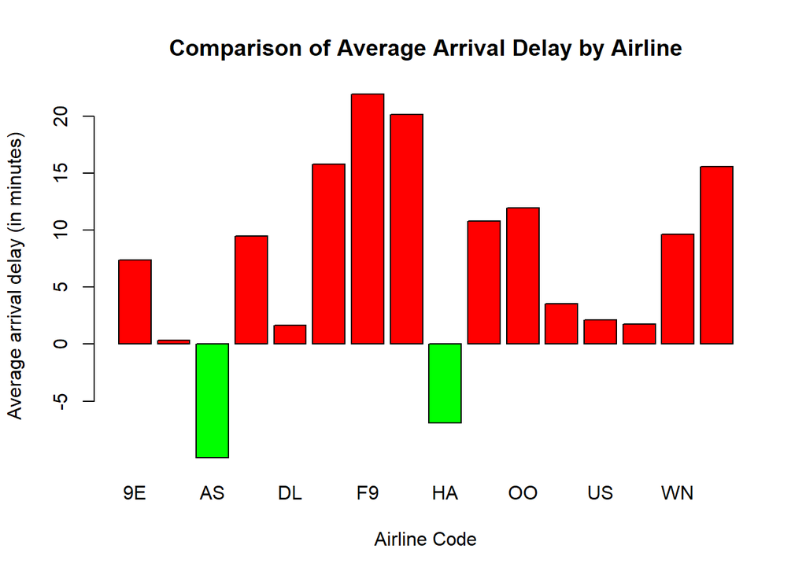

We can see that only two airlines (AS and HA) do not, on average, arrive with a delay. If we are looking for the airline with the least divergence from the expected arrival time, we find that AA performs best with a minimum absolute average arrival delay of .36 minutes.

# 5 Air Gain

Let’s find out whether airlines actually make up time when on air.

## 5.1 Explore airgain data

### 5.1.1 Summary statistics

```r
nyc$air_gain = nyc$dep_delay - nyc$arr_delay
summary(nyc$air_gain)
```

```
##    Min. 1st Qu.  Median    Mean 3rd Qu.    Max.    NA's
## -196.00   -3.00    7.00    5.66   17.00  109.00    9430
```

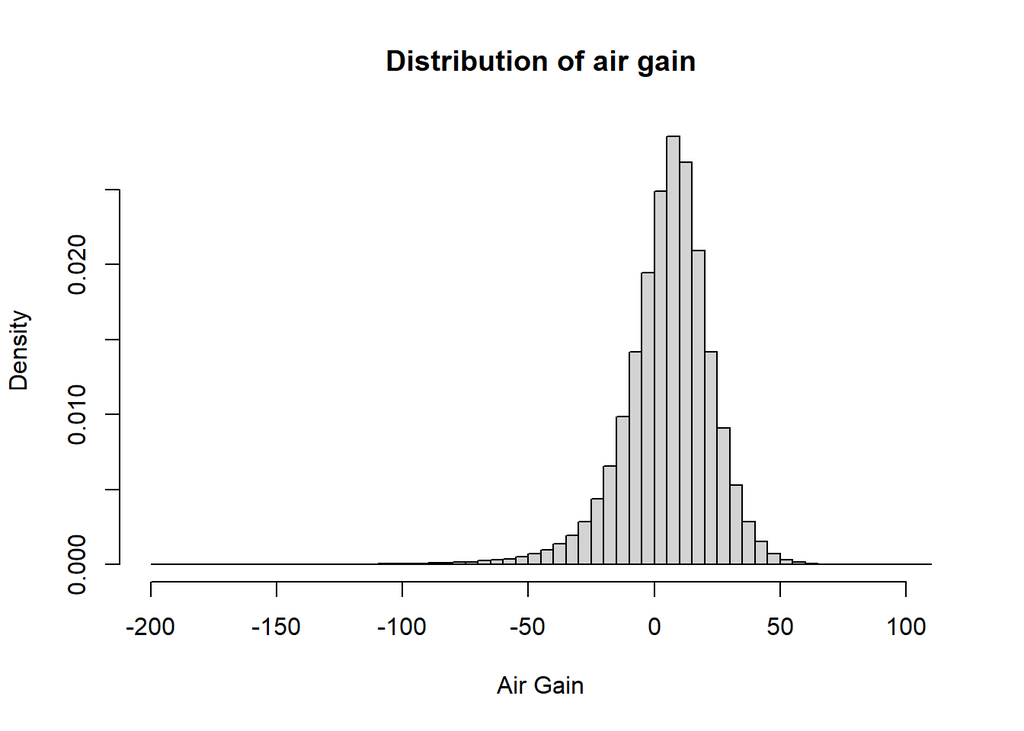

```r
hist(nyc$air_gain, 100, probability = TRUE, main = "Distribution of air gain", xlab = "Air Gain")
```

### 5.1.2 Air Gain by Airline

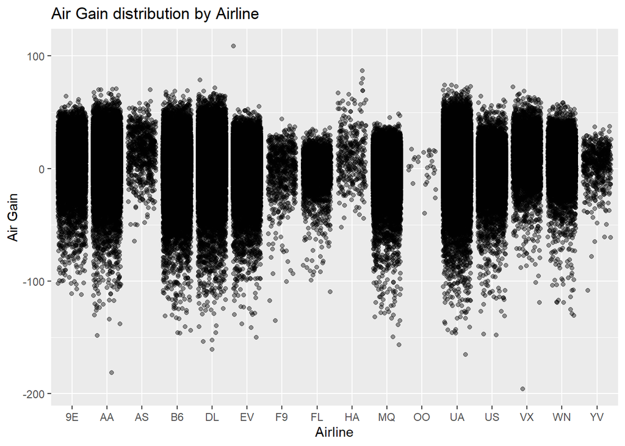

```r
ggplot(data = nyc, aes(x = carrier, y = air_gain)) +
  geom_jitter(alpha = 0.4) +
  labs(
    title = "Air Gain distribution by Airline",
    x = "Airline",
    y = "Air Gain"
  )
```

## 5.2 Questions regarding air gain data

### 5.2.1 Do airlines actually gain any time when in air on average?

```r
mean(na.omit(nyc$air_gain))
```

```
## [1] 5.659779
```

Airlines, on average, do gain time while in the air (approx. 6 minutes in the mean).

### 5.2.2 Which airlines do a better job, which do a worse job?

```r
sort(tapply(nyc$air_gain, nyc$carrier, mean, na.rm = TRUE))
```

```
##         F9         FL         MQ         OO         US         YV         B6
## -1.7195301 -1.5099213 -0.3293526  0.6551724  1.6150976  3.3419118  3.5095746
##         EV         DL         WN         AA         UA         9E         VX
##  4.0424982  7.5796089  8.0125374  8.2048393  8.4588972  9.0599052 10.9921814
##         HA         AS
## 11.8157895 15.7616361
```

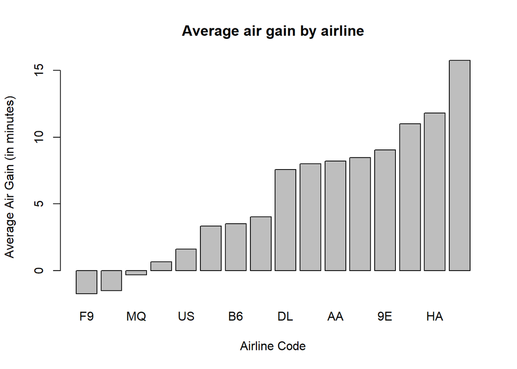

```r
barplot(sort(tapply(nyc$air_gain, nyc$carrier, mean, na.rm = TRUE)), main="Average air gain by airline", xlab="Airline Code", ylab = "Average Air Gain (in minutes)")
```